# EDRM878 Assignment3

Tiejun Zhang

### 5.25. Children were asked to build towers as high as they could out of cubical and cylindrical blocks [2, 9]. The number of blocks used and the time taken were recorded (Table 2.12; data set: blocks). In this problem, only consider the number of blocks used y and the age of the child x.

```r
data(blocks)
summary(blocks)
```

[output not shown]

#### 1.Plot the number of blocks used against the age of the child.

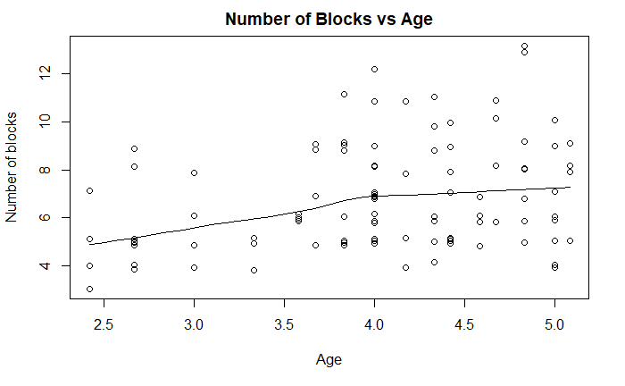

```r
scatter.smooth(jitter(blocks$Number) ~ blocks$Age, main = "Number of Blocks vs Age", xlab = "Age", ylab = "Number of blocks")
```

#### 2.From the plot and an understanding of the data, answer the two questions in Sect. 5.2 (p. 211) for these data, and hence propose a glm for the data.

What probability distribution is appropriate?

The plot indicates a non-linear relationship. Additionally, the variance tends to increases as the mean increases. As the response is the number of blocks(counts), the poisson distribution might be an appropriate option.

```r
# cut age into three groups
age.cut <- cut(blocks$Age, 3)
summary(age.cut)
```

```
(2.42,3.31] (3.31,4.19] (4.19,5.08]
         16          40          44
```

```r
# calculate the mean, varance and length for each age group.
mn <- tapply(blocks$Number, age.cut, "mean")
vr <- tapply(blocks$Number, age.cut, "var")
sz <- tapply(blocks$Number, age.cut, "length")
cbind("Group size" = sz, "Group mean" = mn, "Group variance" = vr)
```

[output not shown]

As we can see from the output, the variance increases as the mean gets larger.

Side-by-side boxplots to present the trend.

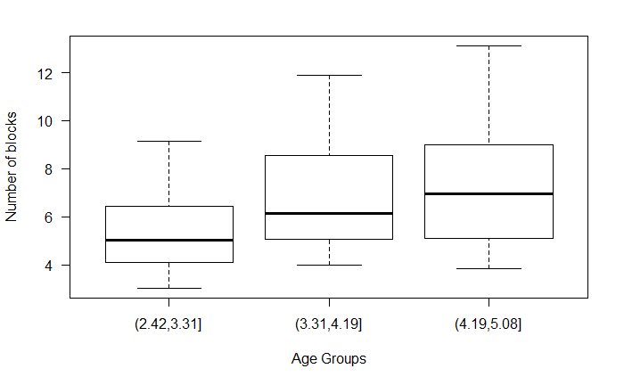

```r
plot(jitter(Number) ~ (age.cut),
     pch = 1,
     las = 1,
     data = blocks,
     xlab = "Age Groups",
     ylab = "Number of blocks")
```

Plot of log of group means against log of group Variance

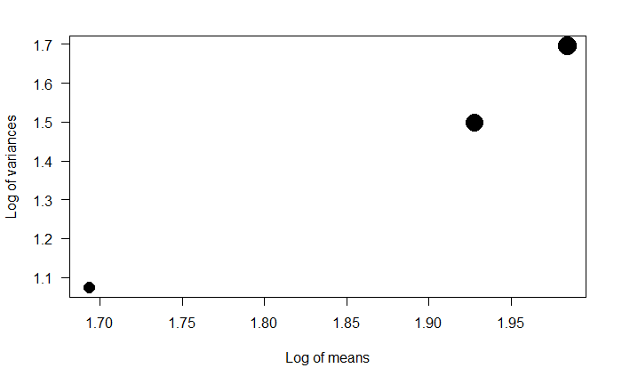

```r
plot(log(vr) ~ log(mn),
     pch = 19,
     las = 1,
     cex = 0.45 * sqrt(sz),
     xlab = "Log of means",
     ylab = "Log of variances")
```

The variance as a function of the mean.

```r
hm.lm <- lm(log(vr) ~ log(mn), weights = sz)
coef(hm.lm)
```

```
(Intercept)     log(mn)
  -2.504326    2.100207
```

```r
confint(hm.lm)
```

```
                 2.5 %   97.5 %
(Intercept) -11.891222 6.882571
log(mn)      -2.794607 6.995021
```

```r
exp(coef(hm.lm)[1])
```

```
(Intercept)
 0.08173067
```

The dispersion index is 0.08 and the variance function is $mean$^2.1.Given the data is discrete in nature, poisson distribution is appropriate.

### 6.10. Children were asked to build towers as high as they could out of cubical and cylindrical blocks [3, 6]. The number of blocks used and the time taken were recorded (data set: blocks). In this problem, only consider the number of blocks used y and the age of the child x. In Problem 5.25, a glm was proposed for these data.

#### 1.Fit this glm using r, and write down the fitted model.

```r
m1 <- glm(Number~Age, data=blocks, family=poisson(link = "log"))
m1
```

[output not shown]

#### 2.Determine the standard error for each regression parameter.

```r
summary(m1)
```

[output not shown]

Both coefficients (beta0 and beta1) have a p value less than 0.05, indicating a strong relationship. The standard error is 0.22 for beta0 and 0.05 for beta1.

#### 3.Compute the residual deviance.

```r
deviance(m1)
```

```
[1] 62.24384
```

The residual deviance is 62.24.